# Final Analysis

## Power Analysis

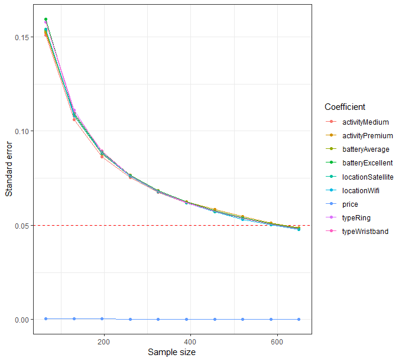

The link between the sample size and the standard error for different coefficients is displayed in this power analysis figure. The standard error falls with increasing sample size, suggesting more accuracy in predicting the coefficients. The graphic also shows that a standard error of 0.05 may be achieved with a sample size of 600. This guarantees that the research is sufficiently powered to derive a trustworthy result on the impact of various product features.

# Modeling

For our final analysis, we have built the models which are listed below.

## Simple Logit Model

The model below considers attributes such as the price of the health tracking device, while the four remaining attributes are dummy coefficients. Dummy coefficients have been used for the attributes below:

*Reference Levels:*

- **Battery:** poor
- **Type:** wristband
- **Activity:** Low
- **Location:** Bluetooth

$$u_j = \beta_1 x_j^{\mathrm{price}} + \beta_2 \delta_j^{\mathrm{ring}}+ \beta_3 \delta_j^{\mathrm{patch}} + \beta_4 \delta_j^{\mathrm{average}} + \beta_5 \delta_j^{\mathrm{excellent}} +
\beta_6 \delta_j^{\mathrm{activMedium}}$$
$$+\beta_7 \delta_j^{\mathrm{activPremium}} + \beta_8 \delta_j^{\mathrm{Wifi}} + \beta_9 \delta_j^{\mathrm{satellite}} +\varepsilon_j$$

### Model coefficients

#### Utility Coefficients

```r
print(coefs)
```

```
#>              price         type_patch          type_ring    battery_average
#>       0.0000957464       0.2725246692       0.0549376331      -0.0820357318
#>  battery_excellent    activity_medium   activity_premium      location_wifi
#>      -0.0858188280      -0.0052037277      -0.1008559138      -0.0220135552
#> location_satellite
#>       0.0183472961
```

```r
print(covariance)
```

```
#>                            price    type_patch     type_ring battery_average
#> price               1.063941e-07 -8.461802e-07 -2.992870e-08   -5.671073e-07
#> type_patch         -8.461801e-07  8.046191e-03  4.175239e-03    3.564378e-05
#> type_ring          -2.992867e-08  4.175239e-03  8.364603e-03    3.890342e-04
#> battery_average    -5.671073e-07  3.564378e-05  3.890342e-04    7.966174e-03
#> battery_excellent   9.642926e-08  3.754649e-05  1.665577e-04    3.875969e-03
#> activity_medium    -1.008342e-06 -7.617739e-05 -1.000033e-04    9.320336e-05
#> activity_premium   -5.640849e-07 -3.853254e-04 -3.830776e-04   -1.729561e-04
#> location_wifi       1.133077e-06  2.484445e-04  1.687398e-04   -2.481703e-04
#> location_satellite  1.769046e-06  9.669451e-05  3.236348e-04   -1.967305e-04
#>                    battery_excellent activity_medium activity_premium
#> price                   9.642934e-08   -1.008342e-06    -5.640850e-07
#> type_patch              3.754649e-05   -7.617739e-05    -3.853254e-04
#> type_ring               1.665577e-04   -1.000033e-04    -3.830776e-04
#> battery_average         3.875969e-03    9.320336e-05    -1.729561e-04
#> battery_excellent       8.156545e-03    2.077415e-04     3.993231e-05
#> activity_medium         2.077415e-04    8.113720e-03     4.309813e-03
#> activity_premium        3.993231e-05    4.309813e-03     8.566627e-03
#> location_wifi          -2.448760e-04   -2.652720e-04    -1.501458e-04
#> location_satellite     -4.493790e-04   -2.050123e-04    -4.359819e-05
#>                    location_wifi location_satellite
#> price               1.133077e-06       1.769046e-06
#> type_patch          2.484445e-04       9.669451e-05
#> type_ring           1.687398e-04       3.236348e-04
#> battery_average    -2.481703e-04      -1.967305e-04
#> battery_excellent  -2.448760e-04      -4.493790e-04
#> activity_medium    -2.652720e-04      -2.050123e-04
#> activity_premium   -1.501458e-04      -4.359819e-05
#> location_wifi       8.224560e-03       3.934430e-03
#> location_satellite  3.934430e-03       7.883625e-03
```